# Taak 10

```python
import pandas as pd
import seaborn as sns

data = pd.read_csv('Data.csv')
```

```python
data.head()
```

|  | Country | League | Club | Player Names | Matches_Played | Substitution | Mins | Goals | xG | xG Per Avg Match | Shots | OnTarget | Shots Per Avg Match | On Target Per Avg Match | Year |
| --- | --- | --- | --- | --- | --- | --- | --- | --- | --- | --- | --- | --- | --- | --- | --- |
| 0 | Spain | La Liga | (BET) | Juanmi Callejon | 19 | 16 | 1849 | 11 | 6.62 | 0.34 | 48 | 20 | 2.47 | 1.03 | 2016 |
| 1 | Spain | La Liga | (BAR) | Antoine Griezmann | 36 | 0 | 3129 | 16 | 11.86 | 0.36 | 88 | 41 | 2.67 | 1.24 | 2016 |
| 2 | Spain | La Liga | (ATL) | Luis Suarez | 34 | 1 | 2940 | 28 | 23.21 | 0.75 | 120 | 57 | 3.88 | 1.84 | 2016 |
| 3 | Spain | La Liga | (CAR) | Ruben Castro | 32 | 3 | 2842 | 13 | 14.06 | 0.47 | 117 | 42 | 3.91 | 1.40 | 2016 |
| 4 | Spain | La Liga | (VAL) | Kevin Gameiro | 21 | 10 | 1745 | 13 | 10.65 | 0.58 | 50 | 23 | 2.72 | 1.25 | 2016 |

## Portfolio assignment 10

15 min: Perform a bivariate analysis (Pearson correlation and scatter plot) on at least 1 combination of 2 columns with numeric data in the dataset that you chose in portfolio assignment 4. Does the correlation and scatter plot match your expectations? Add your answer to your notebook. Commit the Notebook to your portfolio when you're finished.

#### Voor deze opdracht, voer ik een bivarate analysis op de kolommen Goals + (shots) OnTarget uit.

Als hypothese, wil ik weten of het aantal schoten op doel invloed heeft op het aantal doelpunten die een speler maakt. Ik ga ervan uit dat er een sterke relatie is tussen het aantal schoten die een speler maakt en het aantal doelpunten die het oplevert.

```python
resultGoalsOnTarget = data[['Goals', 'OnTarget']].corr()
```

```python
resultGoalsOnTarget.style.background_gradient(cmap='coolwarm', axis=None)
```

|  | Goals | OnTarget |
| --- | --- | --- |
| Goals | 1.000000 | 0.863684 |
| OnTarget | 0.863684 | 1.000000 |

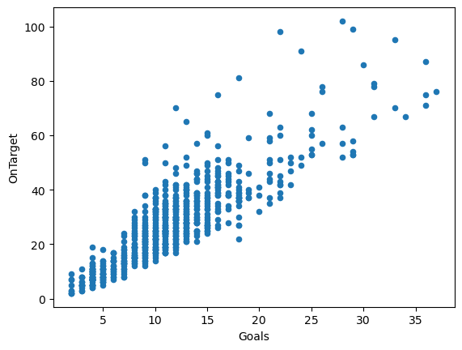

```python
data.plot(kind='scatter', x='Goals', y='OnTarget')
```

#### Uit deze analyse, kan ik volgens de pearson correlation concluderen

dat er een linear verband is tussen het aantal schoten op doel(Shots on target) en het aantal doelpunten dat een speler maakt. Met een score van 0,86 is de verband groot. Als ik mijn hypothese vergelijk met de resultaten, dan komt het resultaat overeen met die van mijn hypothese.

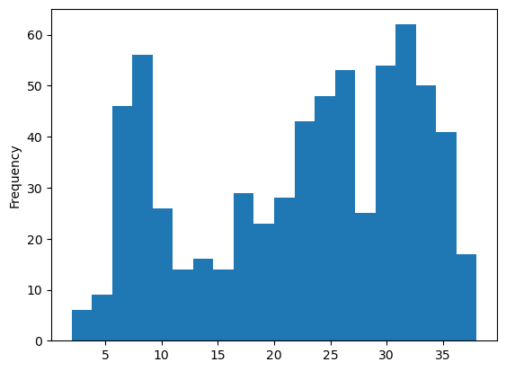

```python
# Een andere analyse zal ook afgenomen worden op de kolommen
data['Matches_Played'].min()
data['Matches_Played'].plot(kind='hist', bins=20)
```

#### Een andere vraagstuk die ik wil weten is of het aantal minuten die een speler speelt in een seizoen, invloed heeft op zijn xG

Mijn hypothese is dat er een sterk verband is tussen het aantal minuten die een speler heeft gemaakt en zijn xG daarop.

```python
# Als een speler minder dan 10 voledige wedstrijden heeft gespeeld.
data[['Mins', 'xG']].corr().style.background_gradient(cmap='coolwarm', axis=None)
```

|  | Mins | xG |
| --- | --- | --- |
| Mins | 1.000000 | 0.708465 |
| xG | 0.708465 | 1.000000 |

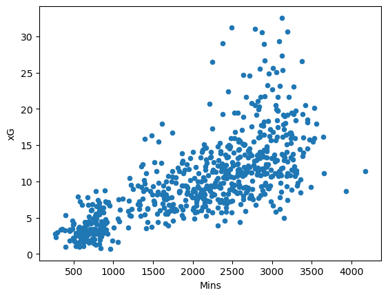

```python
data.plot(kind='scatter', x='Mins', y='xG')
```

#### Ik uit de resultaten ophalen dat er een sterk verband is tussen aantal minuten en xG

Deze conclusie komt overeen met mijn hypothese, maar is minder sterk dan gedacht. 0,7 in plaats van > 0,8

Hierin wil ik weten of het aantal wissels invloed heeft op het aantal doelpunten die een speler maakt Ik ga ervan uit dat er een negatieve verband is tussen de twee waarden en dat het resultaat -0,6 is.

In deze analyse, zal er zowel een analyse worden uitgevoerd met spelers die nooit gewisseld zijn en zonder die spelers.

```python
withoutSub = data[data['Substitution '] > 0]
```

```python
withoutSub[['Substitution ', 'Goals']].corr().style.background_gradient(cmap='coolwarm', axis=None)
```

|  | Substitution | Goals |
| --- | --- | --- |
| Substitution | 1.000000 | -0.032398 |
| Goals | -0.032398 | 1.000000 |

```python
data[['Substitution ', 'Goals']].corr().style.background_gradient(cmap='coolwarm', axis=None)
```

|  | Substitution | Goals |
| --- | --- | --- |
| Substitution | 1.000000 | 0.043922 |
| Goals | 0.043922 | 1.000000 |

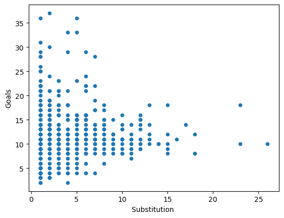

```python
withoutSub.plot(kind='scatter', x='Substitution ', y='Goals')
```

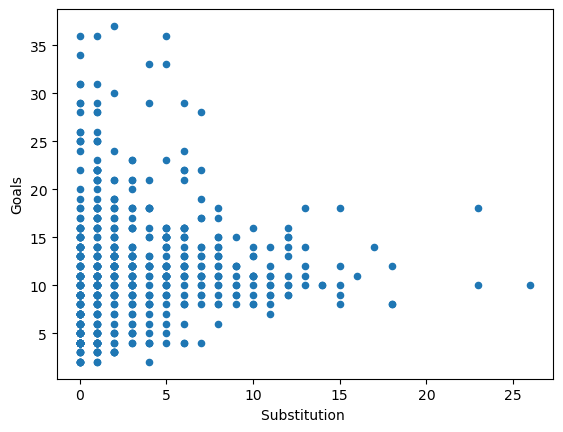

```python
data.plot(kind='scatter', x='Substitution ', y='Goals')
```

De correlatie getal valt veel hoger uit dan gedacht. Daarnaast zat ik fout in de gedachte dat er een verband is tussen aantal substitutions en doelpunten.